# Re-Creating IRA Capacity Deficits

Kevin See

May 11, 2021

<sup>1</sup> Biomark, Inc.

# Introduction

When the IRA report came out, our QRF model included an extrapolation model based on GRTS master sample points (See et al. 2021). Since then, we have updated the extrapolation model to one that is based on a linear network of 200m reaches. This linear network is also based on an updated NHDPlus network, which often increases the length of various streams as the updated version has finer resolution.

To examine the impact of this change in extrapolation models, we re-compiled capacity estimates at the watershed scale for all IRA watersheds, across 3 lifestages and both species. We computed capacity using the master sample points, and also using the 200m reaches. We used the updated NHDPlus network for both, so the total stream kilometers for each watershed is the same. For some small tributaries, there may not be a master sample point on that tributary within the range of that species. In such cases, we have no estimate of the carrying capacity of that tributary, so we set it to zero.

# Methods

We used the same life-history parameters used in the IRA addendum, shown in Table 1.

Table 1: Life history parameters used to translate recovery goals into various life-stages.

| Species | Parameter | Value |
| --- | --- | --- |
| Chinook | Female Ratio | 0.49 |
| Chinook | Redds/Female | 1.00 |
| Chinook | Fecundity | 5290.00 |
| Chinook | Egg:Parr | 0.29 |
| Chinook | Parr:Presmolt | 0.41 |
| Steelhead | Female Ratio | 0.62 |
| Steelhead | Redds/Female | 0.89 |
| Steelhead | Fecundity | 4925.65 |
| Steelhead | Egg:Parr | 0.13 |
| Steelhead | Parr:Presmolt | 0.36 |

# Results

Figure 1 shows the comparison between estimates from points and reaches, along with the 95% confidence intervals, broken down by species and lifestage. These results are shown in Table 2 for Chinook, and Table 3 for steelhead.

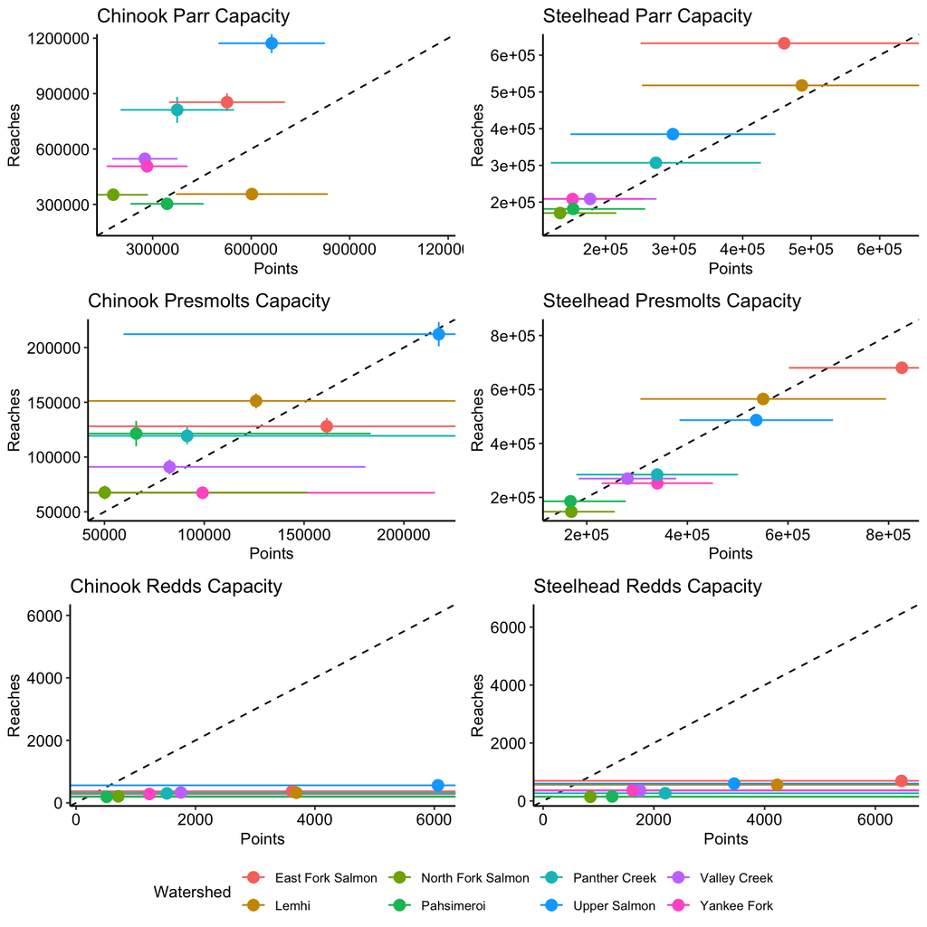

Figure 1: Scatterplots of master sample point estimates (x-axis) vs. linear network estimates (y-axis). The dashed line is the 1-1 line.

The contemporary mean and max of recent escapements (translated to other lifestages), as well as the recovery goal of mean abundance threshold (MAT) and a 25% buffer on top of that (MAT+25%) are shown in Figures 2 - 7, together with estimates of current capacity from master sample points and reaches.

## Chinook

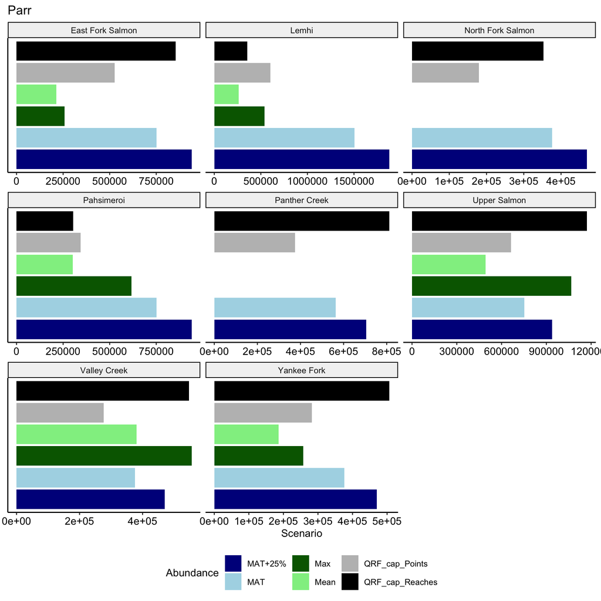

Figure 2: Various scenarios of Chinook parr abundance including QRF capacity estimates.

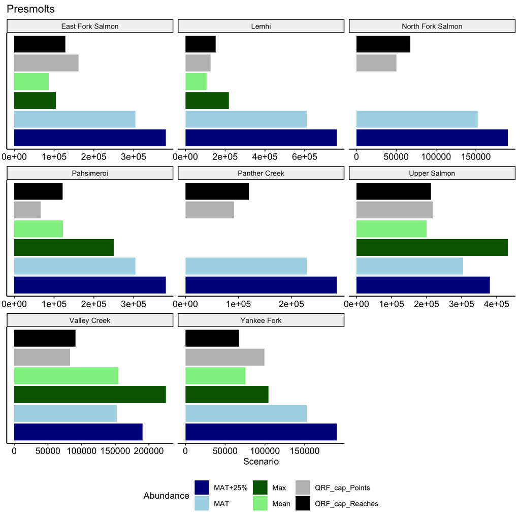

Figure 3: Various scenarios of Chinook presmolt over-winter abundance including QRF capacity estimates.

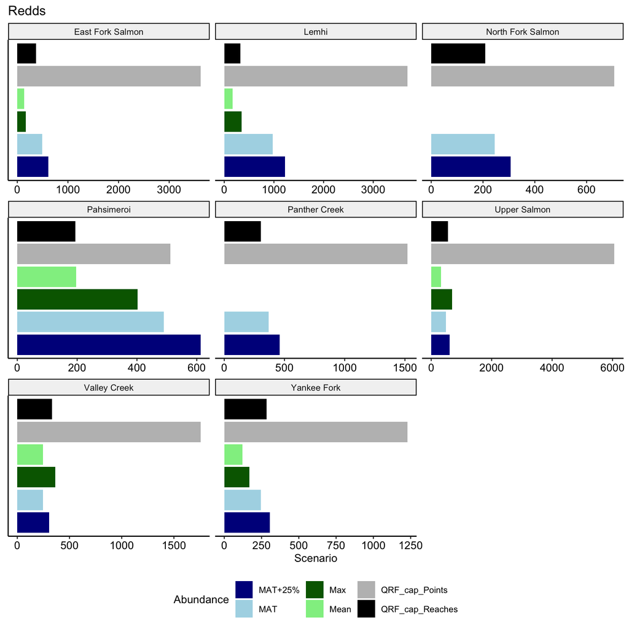

Figure 4: Various scenarios of Chinook redd abundance including QRF capacity estimates.

Table 2: Estimated capacities (CVs) for Chinook in various lifestages using the master sample points and linear network reaches for extrapolation. Total watershed length for each method is shown as well.

| Lifestage | Watershed | Species | Reaches_Length | Points_Length | Reaches_Capacity | Points_Capacity |
| --- | --- | --- | --- | --- | --- | --- |
| Parr | East Fork Salmon | Chinook | 138.8 | 138.9 | 853,474 (0.03) | 526,446 (0.17) |
| Parr | Valley Creek | Chinook | 81.7 | 81.6 | 547,001 (0.03) | 276,176 (0.18) |
| Parr | Yankee Fork | Chinook | 85.7 | 85.8 | 506,498 (0.02) | 282,866 (0.22) |
| Parr | North Fork Salmon | Chinook | 61.8 | 61.9 | 352,402 (0.04) | 179,812 (0.3) |
| Parr | Lemhi | Chinook | 133.4 | 133.5 | 355,902 (0.03) | 602,225 (0.2) |
| Parr | Pahsimeroi | Chinook | 75.3 | 75.3 | 303,251 (0.04) | 343,799 (0.17) |
| Parr | Panther Creek | Chinook | 108.0 | 108.2 | 812,110 (0.04) | 374,684 (0.24) |
| Parr | Upper Salmon | Chinook | 172.7 | 172.8 | 1,172,639 (0.02) | 662,427 (0.12) |
| Redds | East Fork Salmon | Chinook | 138.8 | 138.9 | 372 (0.02) | 3,619 (21.68) |
| Redds | Valley Creek | Chinook | 81.7 | 81.6 | 333 (0.02) | 1,755 (28.52) |
| Redds | Yankee Fork | Chinook | 85.7 | 85.8 | 285 (0.02) | 1,229 (44.14) |
| Redds | North Fork Salmon | Chinook | 61.8 | 61.9 | 208 (0.02) | 707 (70.23) |
| Redds | Lemhi | Chinook | 133.4 | 133.5 | 324 (0.01) | 3,689 (32.43) |
| Redds | Pahsimeroi | Chinook | 75.3 | 75.3 | 193 (0.02) | 512 (119.51) |
| Redds | Panther Creek | Chinook | 108.0 | 108.2 | 304 (0.02) | 1,521 (55.67) |
| Redds | Upper Salmon | Chinook | 172.7 | 172.8 | 562 (0.01) | 6,061 (13.22) |
| Presmolts | East Fork Salmon | Chinook | 138.8 | 138.9 | 128,078 (0.03) | 161,349 (0.53) |
| Presmolts | Valley Creek | Chinook | 81.7 | 81.6 | 91,005 (0.04) | 82,625 (0.61) |
| Presmolts | Yankee Fork | Chinook | 85.7 | 85.8 | 67,409 (0.04) | 99,130 (0.6) |
| Presmolts | North Fork Salmon | Chinook | 61.8 | 61.9 | 67,669 (0.05) | 50,121 (1.04) |
| Presmolts | Lemhi | Chinook | 133.4 | 133.5 | 151,249 (0.02) | 125,945 (0.98) |
| Presmolts | Pahsimeroi | Chinook | 75.3 | 75.3 | 121,490 (0.05) | 65,895 (0.91) |
| Presmolts | Panther Creek | Chinook | 108.0 | 108.2 | 119,376 (0.03) | 91,409 (0.92) |
| Presmolts | Upper Salmon | Chinook | 172.7 | 172.8 | 212,177 (0.03) | 217,462 (0.37) |

## Steelhead

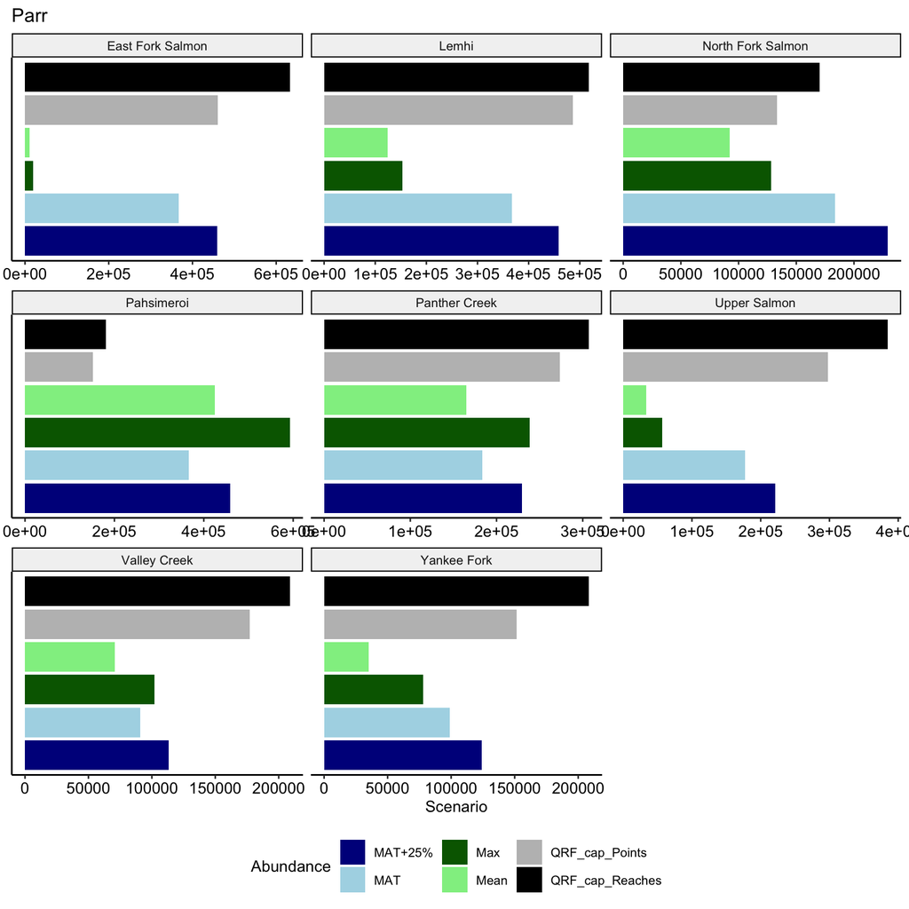

Figure 5: Various scenarios of steelhead parr abundance including QRF capacity estimates.

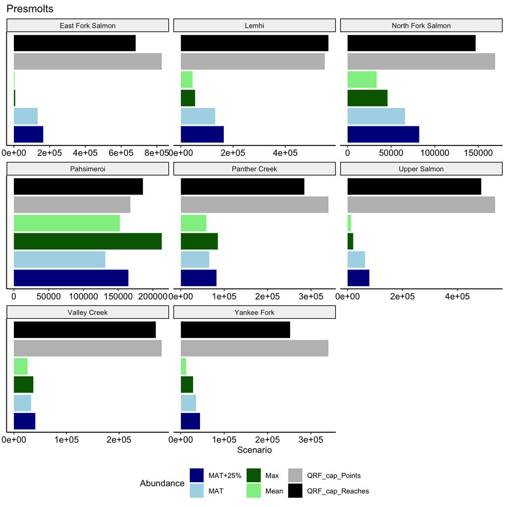

Figure 6: Various scenarios of steelhead presmolt over-winter abundance including QRF capacity estimates.

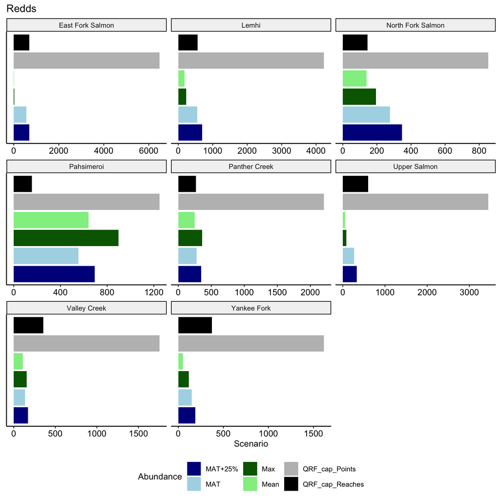

Figure 7: Various scenarios of steelhead redd abundance including QRF capacity estimates.

Table 3: Estimated capacities (CVs) for steelhead in various lifestages using the master sample points and linear network reaches for extrapolation. Total watershed length for each method is shown as well.

| Lifestage | Watershed | Species | Reaches_Length | Points_Length | Reaches_Capacity | Points_Capacity |
| --- | --- | --- | --- | --- | --- | --- |
| Parr | East Fork Salmon | Steelhead | 269.2 | 269.3 | 632,410 (0.01) | 460,594 (0.23) |
| Parr | Valley Creek | Steelhead | 97.9 | 97.8 | 208,720 (0.02) | 177,190 (0.28) |
| Parr | Yankee Fork | Steelhead | 108.6 | 108.7 | 208,371 (0.01) | 151,536 (0.35) |
| Parr | North Fork Salmon | Steelhead | 62.0 | 62.1 | 170,254 (0.03) | 133,375 (0.31) |
| Parr | Lemhi | Steelhead | 236.3 | 236.5 | 517,675 (0.01) | 486,353 (0.24) |
| Parr | Pahsimeroi | Steelhead | 73.5 | 73.5 | 181,416 (0.02) | 152,448 (0.35) |
| Parr | Panther Creek | Steelhead | 120.2 | 120.3 | 307,050 (0.02) | 273,237 (0.29) |
| Parr | Upper Salmon | Steelhead | 185.5 | 185.5 | 384,997 (0.01) | 298,051 (0.26) |
| Redds | East Fork Salmon | Steelhead | 269.2 | 269.3 | 695 (0.01) | 6,470 (17.92) |
| Redds | Valley Creek | Steelhead | 97.9 | 97.8 | 357 (0.02) | 1,752 (28.22) |
| Redds | Yankee Fork | Steelhead | 108.6 | 108.7 | 372 (0.02) | 1,615 (34.32) |
| Redds | North Fork Salmon | Steelhead | 62.0 | 62.1 | 145 (0.02) | 854 (51.16) |
| Redds | Lemhi | Steelhead | 236.3 | 236.5 | 559 (0.01) | 4,226 (29.17) |
| Redds | Pahsimeroi | Steelhead | 73.5 | 73.5 | 155 (0.03) | 1,247 (43.67) |
| Redds | Panther Creek | Steelhead | 120.2 | 120.3 | 268 (0.02) | 2,205 (37.14) |
| Redds | Upper Salmon | Steelhead | 185.5 | 185.5 | 599 (0.01) | 3,450 (22.58) |
| Presmolts | East Fork Salmon | Steelhead | 269.2 | 269.3 | 680,317 (0.01) | 826,428 (0.14) |
| Presmolts | Valley Creek | Steelhead | 97.9 | 97.8 | 269,571 (0.03) | 280,879 (0.18) |
| Presmolts | Yankee Fork | Steelhead | 108.6 | 108.7 | 252,428 (0.02) | 340,304 (0.17) |
| Presmolts | North Fork Salmon | Steelhead | 62.0 | 62.1 | 146,955 (0.03) | 169,328 (0.26) |
| Presmolts | Lemhi | Steelhead | 236.3 | 236.5 | 564,830 (0.02) | 550,633 (0.23) |
| Presmolts | Pahsimeroi | Steelhead | 73.5 | 73.5 | 185,492 (0.03) | 167,614 (0.33) |
| Presmolts | Panther Creek | Steelhead | 120.2 | 120.3 | 284,402 (0.02) | 339,922 (0.24) |
| Presmolts | Upper Salmon | Steelhead | 185.5 | 185.5 | 486,444 (0.02) | 536,919 (0.15) |

## Lemhi Specific

We broke down the Lemhi available capacity into the Upper and Lower Lemhi (defined by the confluence of Hayden Creek).

### Chinook

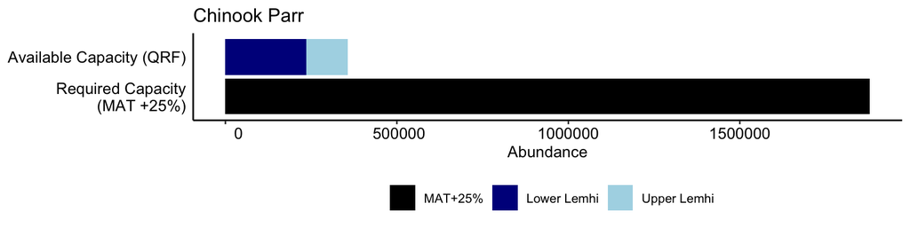

Figure 8: Overall recovery goal of Chinook parr in the Lemhi (MAT +25%) along with available capacity, colored by lower and upper Lemhi.

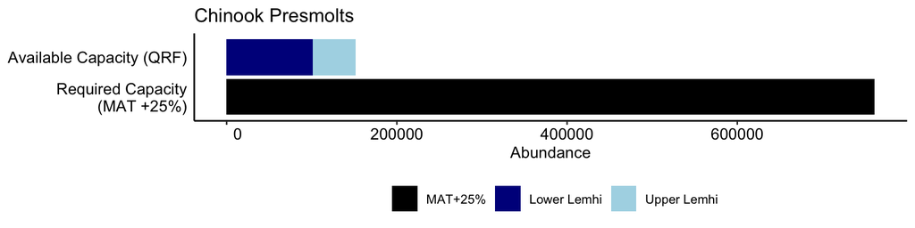

Figure 9: Overall recovery goal of Chinook presmolts (overwintering) in the Lemhi (MAT +25%) along with available capacity, colored by lower and upper Lemhi.

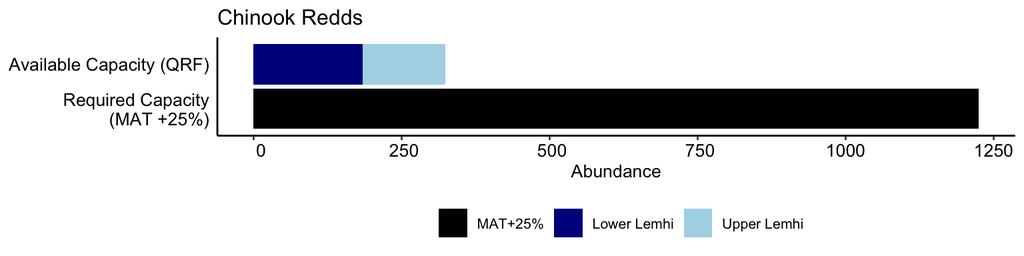

Figure 10: Overall recovery goal of Chinook redds in the Lemhi (MAT +25%) along with available capacity, colored by lower and upper Lemhi.

### Steelhead

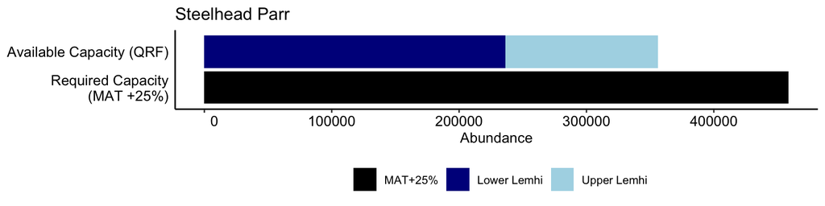

Figure 11: Overall recovery goal of steelhead parr in the Lemhi (MAT +25%) along with available capacity, colored by lower and upper Lemhi.

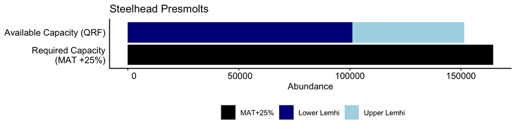

Figure 12: Overall recovery goal of steelhead presmolts (overwintering) in the Lemhi (MAT +25%) along with available capacity, colored by lower and upper Lemhi.

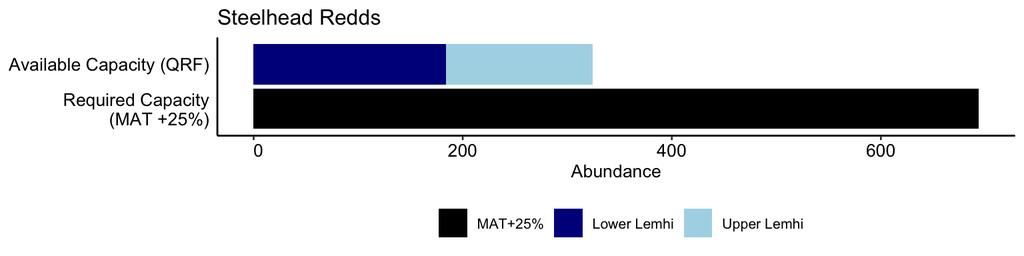

Figure 13: Overall recovery goal of steelhead redds in the Lemhi (MAT +25%) along with available capacity, colored by lower and upper Lemhi.

# Discussion

In general, we noted the following patterns in comparing QRF estimates of capacity using master sample points versus a linear network:

- Chinook parr usually had greater capacity estimates with linear network (with a couple exceptions)
- Chinook presmolts had similar capacity estimates (some smaller, some larger)
- Chinook redds had much smaller capacity estimates with linear network
- Steelhead parr had similar or slightly greater capacity estimates with linear network
- Steelhead presmolts had very similar capacity estimates
- Steelhead redds had much smaller capacity estimates with linear network

We do not believe there is anything inherently incorrect in either extrapolation method. Differences in estimates may arise due to differences in available covariates between master sample points and 200m reaches (and therefore differences in the extrapolation models), but also because the master sample point version must “smooth” across a linear network from a series of points (i.e. taking the average fish/m capacity from points on a stream, and multiplying ny the length of that stream), whereas the 200m reaches are already on a linear network, and we are making extrapolation estimates at every single reach. For this reason, we would recommend using the results from the 200m reach extrapolation going forward.

One of the goals of this exercise was to make as close to apple-to-apples comparisons between estimates based on master sample points and estimates based on 200m reaches on a linear network. It needs to be noted that there are a few streams in the upper Salmon area that are not included in the 200m reach linear network (e.g. Big Springs, Little Springs, Pratt Creek and Lee Creek in the Lemhi, Patterson Side Channels in the Pahsimeroi, Yellowbelly Creek in the Upper Salmon, etc.). Therefore, the estimates for the master sample points presented here may not match those in the IRA report exactly. But because of that, the lengths in Tables 2 and 3 are nearly identical, so any differences in capacity estimates here are not simply due to different species ranges being used; we tried to put them on a level playing field in that regard. This does mean that the linear network could be improved, especially in the Lemhi (and less so in the Pahsimeroi) to allow the 200m reach extrapolation to include those missing streams. That will involve generating not just shapefiles of the stream lines, but either calculating directly or finding a proxy for the various covariates that need to be attached to each reach for the extrapolation model.

# References

See, K. E., M. W. Ackerman, R. A. Carmichael, S. L. Hoffman, and C. Beasley. 2021. Estimating carrying capacity for juvenile salmon using quantile random forest models. Ecosphere.